# Project 3

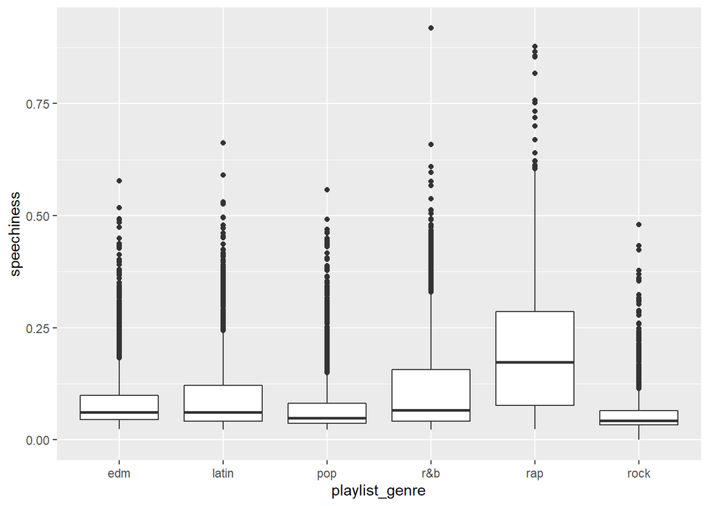

```r
ggplot(spotify_train, aes(x = playlist_genre, y = speechiness)) +
  geom_boxplot()
```

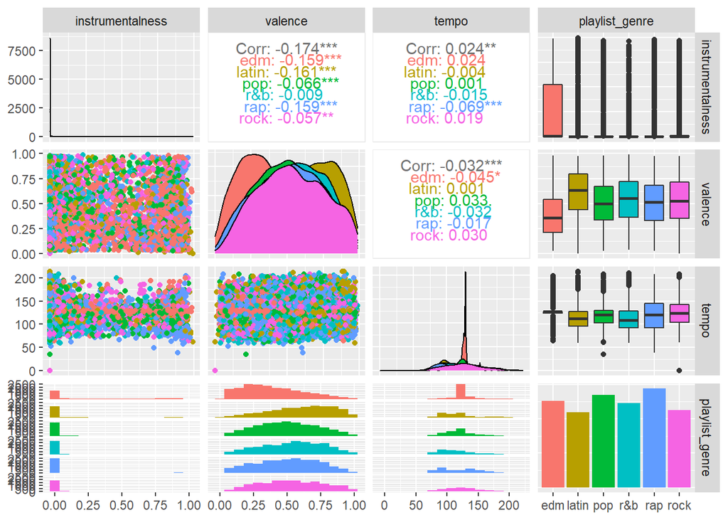

```r
## a scatterplot matrix (pairs plot) with the GGally package that has 3 or 4 candidate predictors, along with playlist_genre

library(GGally)
## instrumentalness, valence and tempo
ggpairs(data = spotify_train, columns = c(19, 21, 22, 10),
        lower = list(combo = wrap(ggally_facethist, bins = 15)),
        mapping = aes(color =playlist_genre))
```

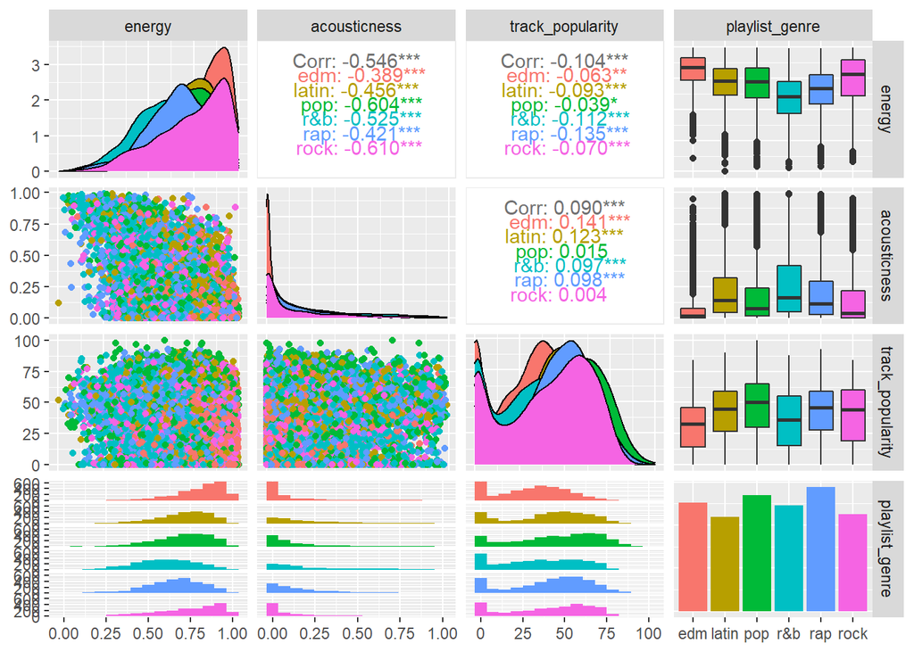

```r
## energy, accousticness, track_popularity
ggpairs(data = spotify_train, columns = c(13, 18, 4, 10),
        lower = list(combo = wrap(ggally_facethist, bins = 15)),
        mapping = aes(color =playlist_genre))
```

From the boxplots and bar plots above, it apparent that there other predictors that appear to be more useful. Predictors such as energy, acousticness, instrumentalness, valence, tempo, track popularity, and speechiness will be used in my initial model.

## Methods

Since the goal is to predict the playlist_genre, the general genre of the song, from characteristics of the songs with a k-nearest-neighbors model. I might need to explain what a k-nearest-neighbors model is. It is a machine learning algorithm or model that is used for classification and regression. This means that it is used to predict a response variable given a two or more variables. The response variable can be either categorical or quantitative. This algorithm relies on distance for classifying test data. Given an integer k, we can use this to predict the response is we look at what the k nearest neighbors are or observations are. To use a knn model or any predictive/classification model we need to have a train sample and test sample. The train sample is the subset data set from the original data set that we use to fit or train the model. While the test sample is the one that we use to test or access the performance or accuracy of our model. We need to use these separately because it would not make sense for us to use the same data set to train and test because that would give a higher accuracy which is false. We have to use data that is new to the model. Because we use distance between points to predicts, these distances can vary in scales and sizes and thus we need to scale all the quantitative variables to get a better sense of the distance of the points.

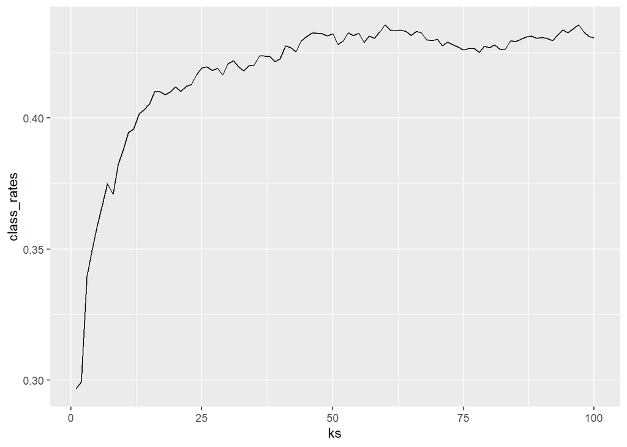

```r
## scale any/all candidate predictors in both the training
## and the test data sets before you fit the knn model.

spotify_train_scaled<- spotify_train |>
  mutate(across(where(is.numeric), ~ (.x - min(.x)) /
                                 (max(.x) - min(.x))))

spotify_test_scaled<- spotify_test |>
  mutate(across(where(is.numeric), ~ (.x - min(.x)) /
                                 (max(.x) - min(.x))))

library(class)
## create a data frame that only has the predictors
## that we will use
spotify_train_knn <- spotify_train_scaled |>
  select(energy, acousticness, track_popularity,
         instrumentalness, valence, tempo,
         speechiness, duration_ms, mode, loudness)
spotify_test_knn <- spotify_test_scaled |>
  select(energy, acousticness, track_popularity,
         instrumentalness, valence, tempo,
         speechiness, duration_ms, mode, loudness)


## put our response variable into a vector
train_cat <- spotify_train_scaled$playlist_genre
test_cat <- spotify_test_scaled$playlist_genre

## function
get_class_rate <- function(k = 10) {

knn_model <- knn(train = spotify_train_knn, test = spotify_test_knn,
                   cl = train_cat, k = k)

res_tab1 <- table(knn_model, test_cat)
sum(diag(res_tab1)) / sum(res_tab1)
}

class_rates <- map(1:100, get_class_rate) |> unlist()
class_rate_df <- tibble(ks = 1:100, class_rates)

ggplot(data = class_rate_df,
       aes(x = ks, y = class_rates)) +
  geom_line()
```

```r
class_rate_df |> filter(class_rates == max(class_rates))
```

```
# A tibble: 2 × 2
     ks class_rates
  <int>       <dbl>
1    60       0.435
2    97       0.435
```

```r
## I end up choosing k = 60
```

## Results

- For my final model I used the following predictors:
  - energy,
  - acousticness,
  - track_popularity,
  - instrumentalness,
  - valence,
  - tempo,
  - speechiness,
  - duration_ms,
  - mode,
  - loudness

I also selected a k = 60 because it gave the highest classification rate.

# Confusion matrix

```r
knn_model_2 <- knn(train = spotify_train_knn, test = spotify_test_knn,
                   cl = train_cat, k = 60)

res_tab1_2 <- table(knn_model_2, test_cat)
diag_value <- sum(diag(res_tab1_2)) / sum(res_tab1_2)

off_diag_value <- 1 - diag_value

res_tab1_2
```

```
           test_cat
knn_model_2 edm latin pop r&b rap rock
      edm   467    45  79  23  53   94
      latin  93   233 139  66  57   64
      pop   157   121 342  69 111  151
      r&b    83   147 172 380 140  158
      rap    61   124  95 142 477   24
      rock   45    79 101  86  43  279
```

```r
obj <- list(training = spotify_train_knn,
     cl = train_cat,
     k = 60,
     student_name = "Rodrick Mpofu")
saveRDS(obj, file = "Mpofu_Rodrick.RData")
```